# Data visualization with ggplot2

Visualizing data in R with the ggplot2 package

### Learning Objectives

> - Visualize data using R ggplot2 package
> - Build step-by-step complex plots with the ggplot2 package

For more details and additional tutorials on using ggplot2, see the [official documentation](http://docs.ggplot2.org/current/).

Load required packages.

```r
library(dplyr)
library(ggplot2)
```

Load or reload NHTS data.

The `read_csv()` function has a handy `na = c(...)` input that allows us to quickly deal with the many, many definitions of missing that NHTS has.

```r
nhts_per <- readr::read_csv("data/nhts_per.csv",
                            na = c("", "NA", -1, -8, -5, -4)) %>%
  select(HOUSEID, HHSIZE, HHVEHCNT, TIMETOWK, YEARMILE, USEPUBTR)
```

## `ggplot2` Basics

We will make two plots using the `ggplot2` package. `ggplot2` is a plotting package that makes it simple to create complex plots from data in a dataframe. It uses default settings, which help create publication quality plots with a minimal amount of settings and tweaking.

`ggplot2` graphics are built step by step by adding elements.

To build a ggplot we need to:

1. Bind the plot to a specific data frame using the `data` argument.

```r
ggplot(data = nhts_per)
```

2. Define aesthetics (`aes`), which maps variables in the data to axes on the plot or to plotting size, shape color, etc.

Think of `aes()` like the `data_frame()` function we used before.

```r
ggplot(data = nhts_per, aes(x = TIMETOWK, y = YEARMILE))
```

3. Add `geoms`, which define the graphical representation of the data in the plot (points, lines, bars). To add a geom to the plot use `+` operator. Anything you put in the `ggplot()` function can be seen by any geom layers that you add.

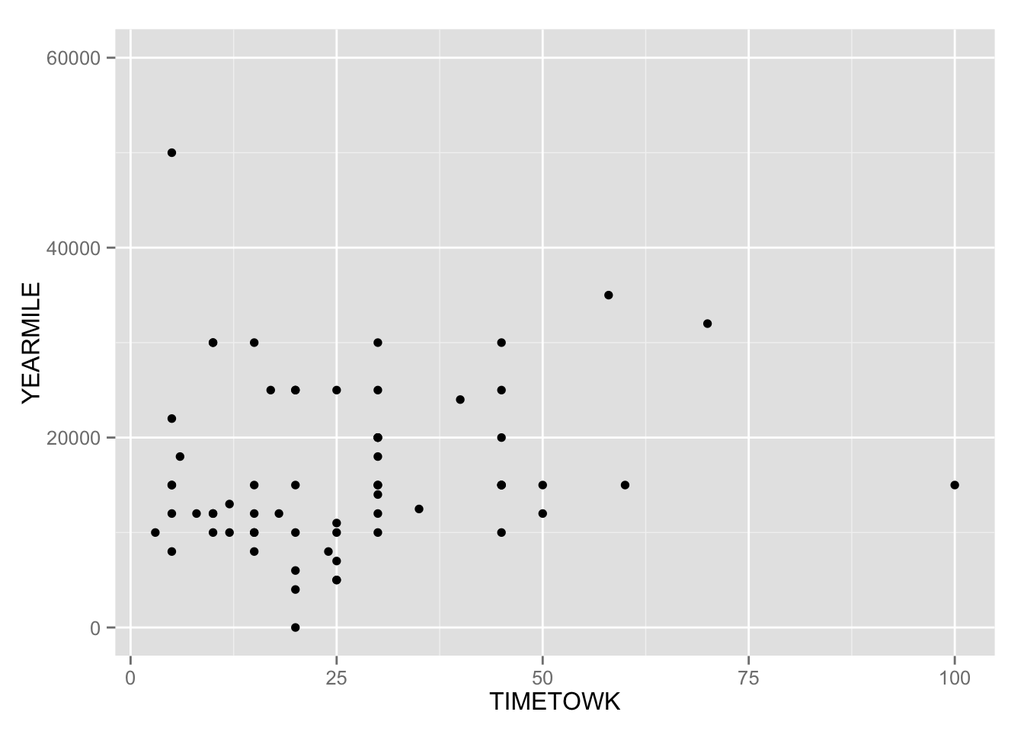

```r
ggplot(data = nhts_per, aes(x = TIMETOWK, y = YEARMILE)) +
  geom_point()
```

4. (optional) Add better labeling.

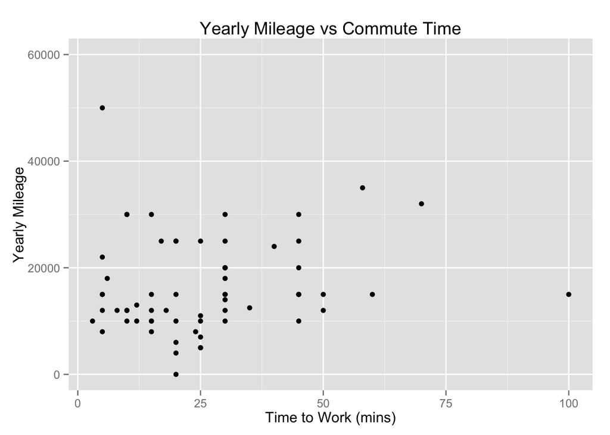

```r
ggplot(data = nhts_per, aes(x = TIMETOWK, y = YEARMILE)) +
  geom_point() +
  labs(title = 'Yearly Mileage vs Commute Time',
       x = 'Time to Work (mins)',
       y = 'Yearly Mileage')
```

5. (optional) Add a theme if you want.

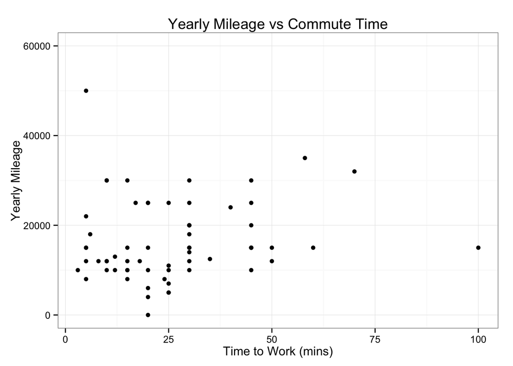

```r
ggplot(data = nhts_per, aes(x = TIMETOWK, y = YEARMILE)) +
  geom_point() +
  labs(title = 'Yearly Mileage vs Commute Time',
       x = 'Time to Work (mins)',
       y = 'Yearly Mileage') +
  theme_bw()
```

Sometimes adding color and transparency adds meaning to the plot. In this case, since we limited the number of rows of the NHTS data to 200, there is not much overlap. But with a lot of points, alpha can be very helpful.

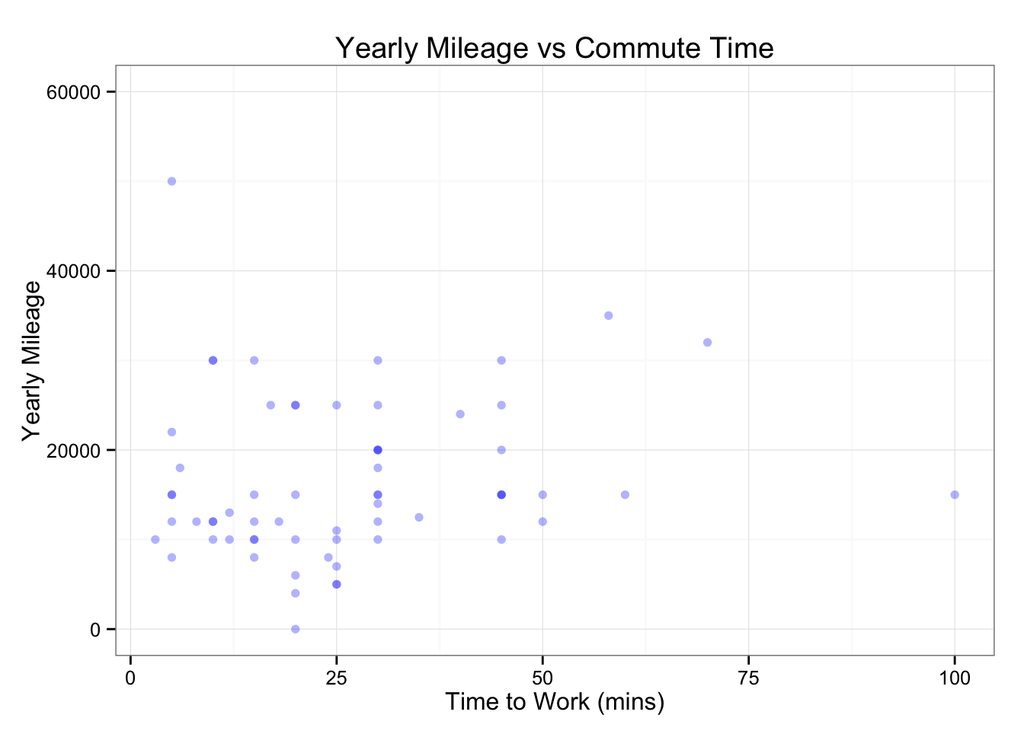

```r
ggplot(data = nhts_per, aes(x = TIMETOWK, y = YEARMILE)) +
  geom_point(alpha = 0.3, color = "blue") +
  labs(title = 'Yearly Mileage vs Commute Time',
       x = 'Time to Work (mins)',
       y = 'Yearly Mileage') +
  theme_bw()
```

## Barplot

Let’s try a barplot.

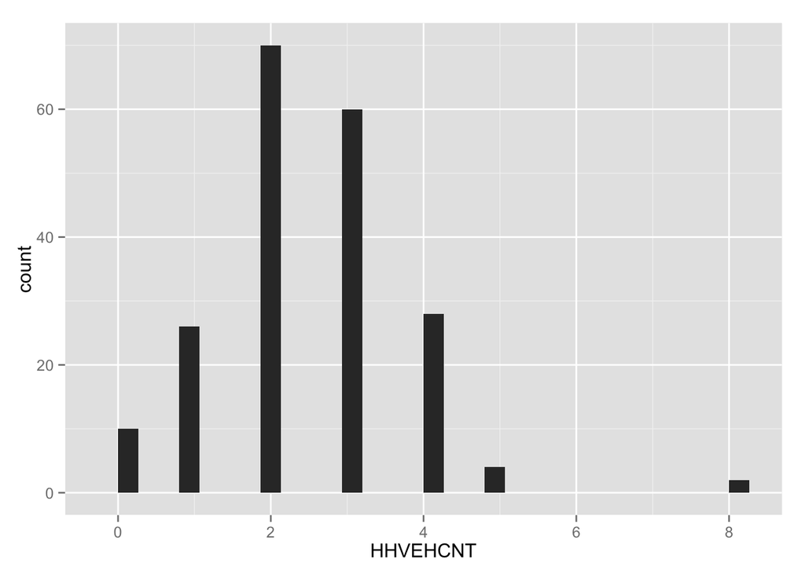

```r
ggplot(data = nhts_per, aes(x = HHVEHCNT)) +
  geom_bar()
```

But this looks a bit funny right? What if, for example, NHTS coded “8” to actually be any household with 8 or more vehicles. We can instead treat this variable as categories, which in R are called factors.

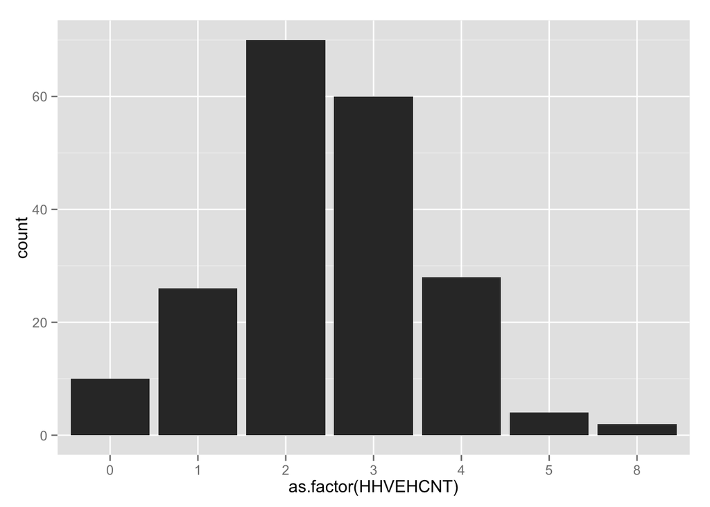

```r
ggplot(data = nhts_per, aes(x = as.factor(HHVEHCNT))) +
  geom_bar() +
  scale_fill_brewer()
```

Then maybe we want to get even fancier and see how household size plays into this distribution.

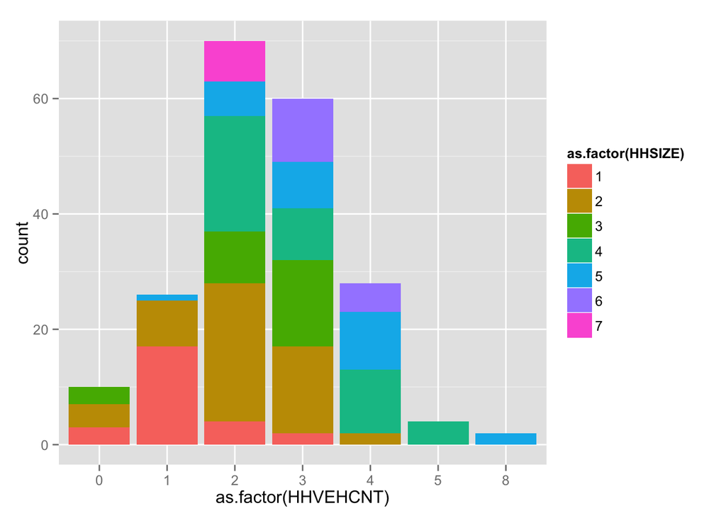

```r
ggplot(data = nhts_per, aes(x = as.factor(HHVEHCNT),
                            fill = as.factor(HHSIZE))) +
  geom_bar()
```

And maybe we don’t like those colors, so we’ll change them.

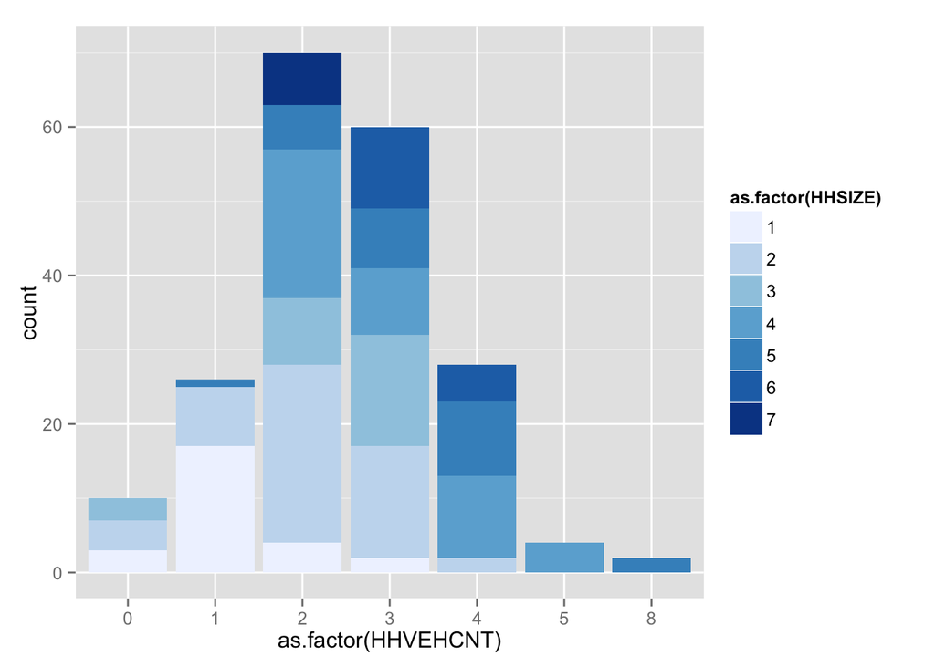

```r
ggplot(data = nhts_per, aes(x = as.factor(HHVEHCNT),
                            fill = as.factor(HHSIZE))) +
  geom_bar() +
  scale_fill_brewer()
```